# SIP/DLA Data Visualization Workshop

### IV. Continuous Data Plots

Continuous data plots can be represented using box/violin plots, but often we are aggregating a large number of data points to represent a mean continuous value for a particular group (e.g., RTs, formant frequencies, eye-tracking values, length/duration, etc.). These means are often represented as connected points, or points with standard deviation/standard error, so we can see how much the individual values vary. In this case, our data needs some manipulation first.

To examine continuous data manipulation and plotting, we will use the **vowels** data set which is included in this project.

*About this Data: This data was collected in 2016-2017 as part of the completion of a Master’s project at North Carolina State University. The data frame contains information about voicing-dependent vowel duration (column vduration, in seconds). Voicing-depending vowel duration is a strong feature of English, wherein vowels tend to be longer when preceding voiced consonants such as /b, d, g/, compared to when they precede voiceless consonants /p, t, k/ (column consonant, column voicing). I examined this phenomenon in both open- and closed-syllable configurations, both word-internally and word-finally (column context), in English and Spanish words (column target), produced by L1 English and L1 Spanish participants (column l1). There are 1620 data points of measured vowel duration, which we can analyze against other categorical variables.*

```r
head(vowels.raw)
```

```
##   speaker  l1 target vowel    word vduration syllables srduration speechrate
## 1    fbe5 eng    eng     a oddball 0.1257376         4  1.0333024   3.871084
## 2    fbe3 eng    eng     a oddball 0.1302244         4  1.3182274   3.034378
## 3    fbe4 eng    eng     a oddball 0.1712580         4  1.1961164   3.344156
## 4    mbe1 eng    eng     a oddball 0.1458752         4  0.9416049   4.248066
## 5    mbe2 eng    eng     a oddball 0.1703062         4  1.3978842   2.861467
## 6    mbe4 eng    eng     a oddball 0.1617398         4  1.7290014   2.313474
##   consonant    place voicing vowelht vowelbk context  X
## 1         d alveolar  voiced    baja central  closed NA
## 2         d alveolar  voiced    baja central  closed NA
## 3         d alveolar  voiced    baja central  closed NA
## 4         d alveolar  voiced    baja central  closed NA
## 5         d alveolar  voiced    baja central  closed NA
## 6         d alveolar  voiced    baja central  closed NA
```

```r
# Note, extra column X may load. This column is meaningless!
```

We can use basic box plots to show the distribution of data, but if we want to quickly examine a figure and get the main takeaway, this can get a little busy.

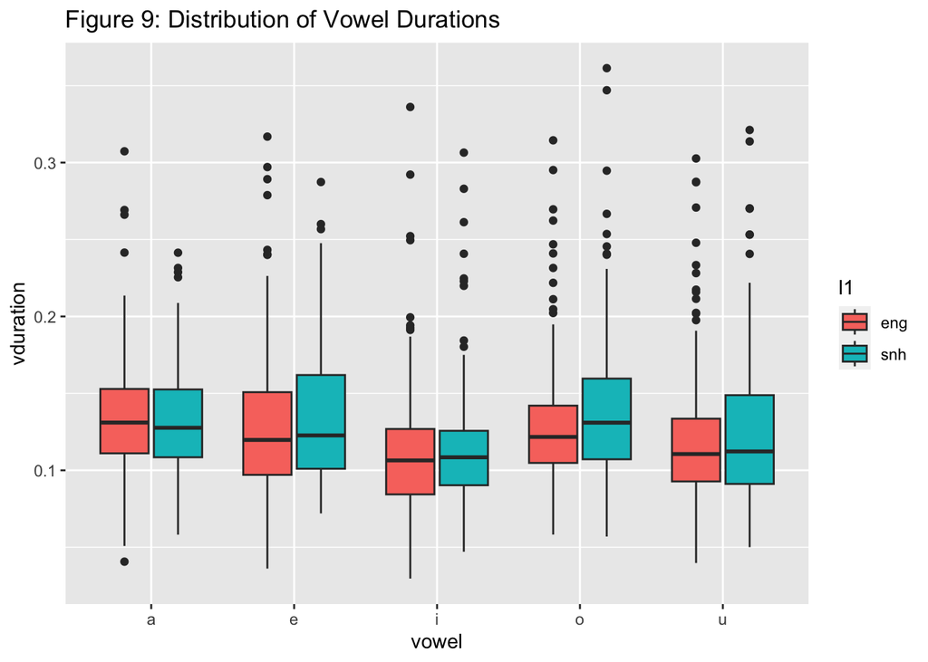

```r
ggplot(vowels.raw, aes(x=vowel, y=vduration, fill=l1))+
  geom_boxplot()+
  labs(title="Figure 9: Distribution of Vowel Durations")
```

In addition, if you are familiar with vowel research, you will know that vowel length is different given certain characteristics such as height. So, we need a plot that is better representative of the data.

In this case, it is more useful to calculate *means* for vowel length given certain factors. To accomplish this, we can create summary statistics using dplyr, and then we can plot those descriptive statistics, *from within the pipe function*.

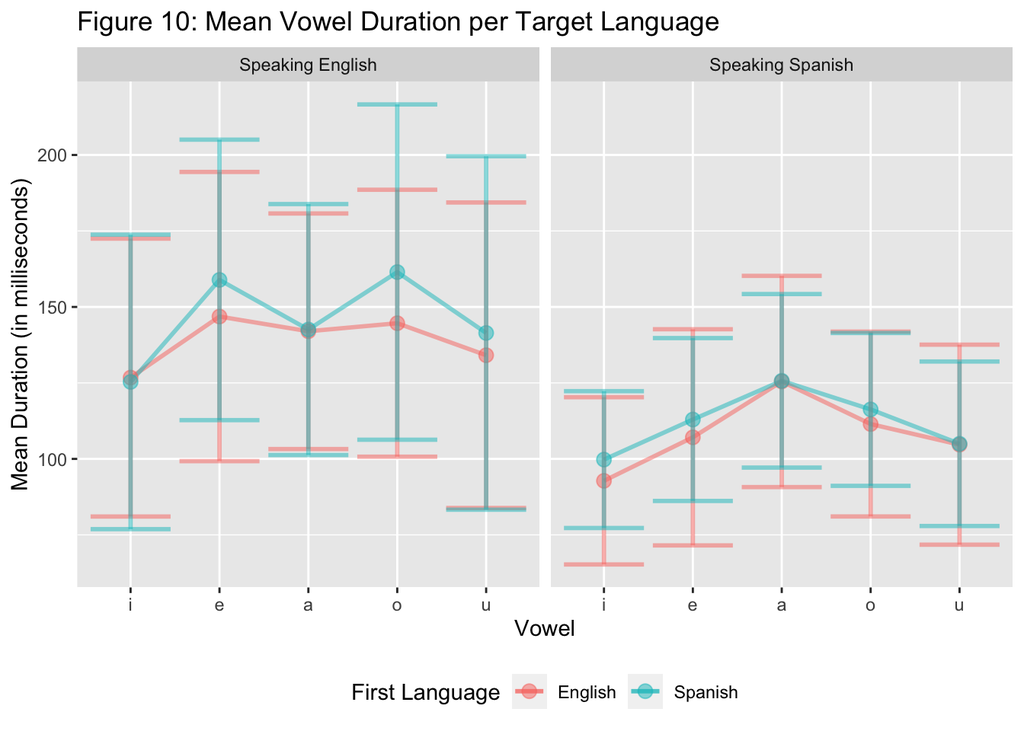

```r
vowels.raw %>%
  # I want the mean vowel duration for each L1 group, and each target language they are speaking in
  group_by(vowel, l1, target) %>%
  summarize(mean(vduration), sd(vduration)) %>%
  # Now here I enter the same plot code I would type out by itself, but in the pipe:
  ggplot(aes(x=factor(vowel, levels=c("i", "e", "a", "o", "u")), y=`mean(vduration)`, color=l1)) +
  # Note the alpha (transparency) change here so you can see more about how the bars/points overlap.
    geom_line(aes(group=l1), alpha = 0.5, linewidth=1)+
    geom_point(alpha=0.5, size=3)+
  # Error pars created with the summarize function above, show standard deviation of vowel duration for each vowel.
    geom_errorbar(aes(ymin=`mean(vduration)`-`sd(vduration)`, ymax=`mean(vduration)`+`sd(vduration)`), alpha=0.5, linewidth=1)+
    facet_grid(.~target, labeller=as_labeller(c(eng="Speaking English", snh="Speaking Spanish")))+
    xlab("Vowel")+
    ylab("Mean Duration (in milliseconds)")+
  # Converting the y axis back to milliseconds
    scale_y_continuous(labels=function(x)x*1000)+
    labs(title="Figure 10: Mean Vowel Duration per Target Language")+
    scale_color_discrete(name="First Language", labels=c("English", "Spanish"))+
    theme(legend.position="bottom")
```